# Conceptos básicos de imágenes

## 12 11. Ejercicios sugeridos

A continuación tienes varios ejercicios que van de lo más básico a algo más analítico.

### 12.1 Ejercicio 1: inspección básica de la imagen

Imprime la forma, el tipo de dato y el valor mínimo y máximo de la imagen.

```python
print("Forma:", img.shape)
print("Tipo:", img.dtype)
print("Mínimo:", img.min())
print("Máximo:", img.max())
```

```
Forma: (670, 1072, 3)
Tipo: uint8
Mínimo: 0
Máximo: 255
```

### 12.2 Ejercicio 2: píxel concreto

Accedé a un píxel en una posición dada y observá sus valores.

```python
x, y = 200, 150
pixel = img[y, x]
print(f"Píxel en ({x},{y}):", pixel)
```

```
Píxel en (200,150): [  3  85 197]
```

### 12.3 Ejercicio 3: canal rojo

Extraé el canal rojo y observá cómo cambia la visualización.

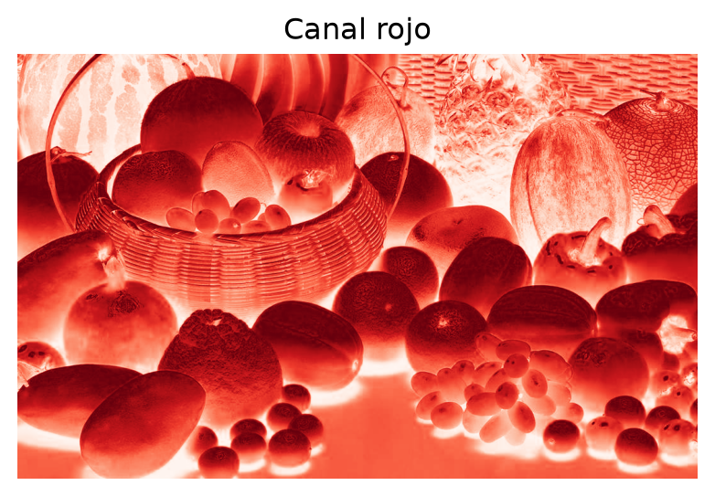

```python
red_channel = img[:, :, 2]
plt.figure(figsize=(5,5))
plt.imshow(red_channel, cmap="Reds")
plt.title("Canal rojo")
plt.axis("off")
plt.show()
```

### 12.4 Ejercicio 4: comparación entre canales

Visualizá por separado los canales B, G y R.

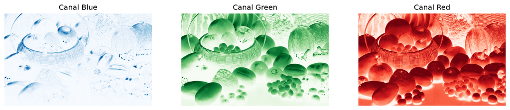

```python
b, g, r = cv2.split(img)

fig, axes = plt.subplots(1, 3, figsize=(15, 5))

axes[0].imshow(b, cmap="Blues")
axes[0].set_title("Canal Blue")
axes[0].axis("off")

axes[1].imshow(g, cmap="Greens")
axes[1].set_title("Canal Green")
axes[1].axis("off")

axes[2].imshow(r, cmap="Reds")
axes[2].set_title("Canal Red")
axes[2].axis("off")

plt.show()
```

### 12.5 Ejercicio 5: conversión a escala de grises

Convertí la imagen a escala de grises y compará la estructura.

```
Forma en grises: (670, 1072)
```

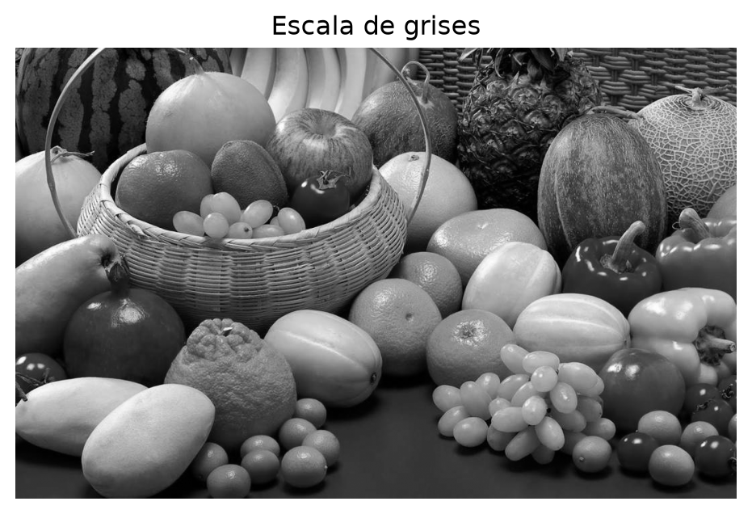

```python
gray = cv2.cvtColor(img, cv2.COLOR_BGR2GRAY)
print("Forma en grises:", gray.shape)

plt.figure(figsize=(6, 6))
plt.imshow(gray, cmap="gray")
plt.title("Escala de grises")
plt.axis("off")
plt.show()
```